# Figure 2

- This code makes all input figures for Figure 2 of Gardner et. al. Controbution of Retrotransposition to Developmental Disorders (2019)
- All Figures need some cleaning up and processing in Illustrator

Load all libraries necessary for this notebook to work and setup basic stuff:

- libraries
- default graphpad-like theme
- function for calculating confidence intervals
- Default MEI color palette

# Genomic Compartment Annotation

- First do an intersect to enhancers, and then remove those sites from the the subsequent file and annotate the rest of the variants
- Annotates **ALL** variants in the VCF (so not the subset used for 2b) - This means that both affected parents and probands are included in totals.
- All compartments are calculated independently, for the purposes of the plot I summed the following categories to make the plot cleaner:
  - UTR
    - 5’ UTR
    - 3’ UTR
  - Enhancers
    - Heart
    - Conserved
    - VISTA
- The key seen in the final figure is done completely in Illustrator, so if deleted has to be made again

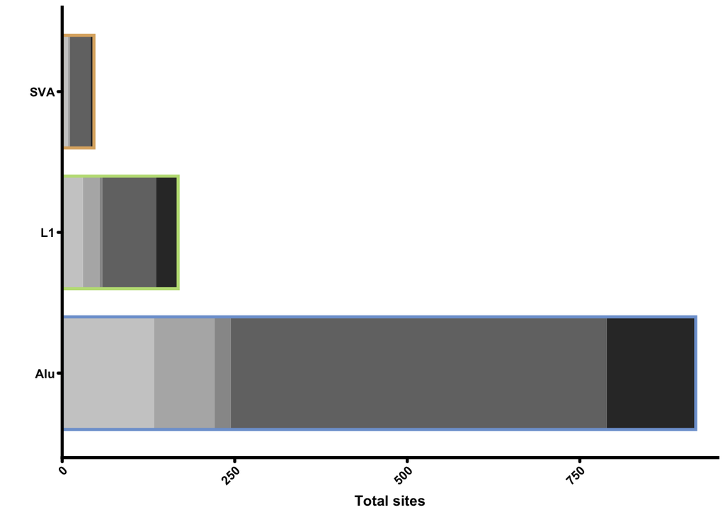

```r
comps<-c("exon","intron","UTR","enhancer","none")

##Script to generate numbers automatically @ : scripts/annotation.sh
##Numbers were then added by hand from the output
annote<-data.table(compartment=rep(comps,3),
                  count=c(128,545,23,88,133,
                          31,78,4,24,30,
                          4,30,0,3,8),
                  mei=c(rep("Alu",5),rep("L1",5),rep("SVA",5)))

annote[,compartment:=factor(compartment,levels=comps)]

## This just makes the coloured border around each MEI bar.
## This + 5 was based off of how the figure looks at the width I have it in the final figure. Doesn't mean anything
fake<-annote[,sum(count)+5,by=mei]

setkey(annote,compartment)

plot.compartment <- ggplot(annote,aes(mei,count,group=compartment,fill=compartment)) + geom_col(size=0,colour="black",width=0.8) + ylab("Total sites") + xlab("") + scale_fill_grey() + scale_x_discrete() + scale_y_continuous(expand=c(0,0),limits = c(0,950)) + geom_col(inherit.aes=F,data=fake,aes(mei,V1-4,colour=mei),alpha=0,size=1,width=0.8) + scale_colour_manual(values=cPalette) + theme + coord_flip()

plot.compartment
```

## Compare total number of coding variants to 1KGP:

This is in the Supplemental data as Supplemental Figure 7

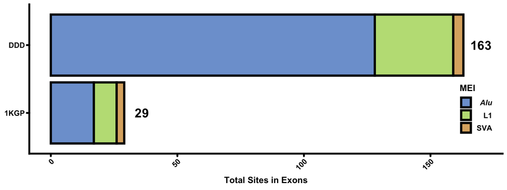

```r
cbbPalette <- c("#7DA1D4","#BEDE85","#DCB070")

coding_proportion <- fread("RawData/coding_proportion.txt")

theme.custom <- theme %+replace% theme(legend.position=c(0.9,0.3))

ggplot(coding_proportion[MEI!="Total"],aes(Dataset,Count,group=Dataset,fill=MEI)) + scale_fill_manual(values=cbbPalette,labels=c(expression(bolditalic("Alu")),"L1","SVA")) + geom_col(colour="black",size=1.2) + ylab("Total Sites in Exons") + xlab(NULL) + geom_text(data=coding_proportion[MEI=="Total"],inherit.aes=F,aes(Dataset,Count,group=Dataset,label=Count),position=position_nudge(x=0,y=7),fontface="bold",size=5) + coord_flip() + theme.custom
```

# Generate pLI and Singleton numbers for Figure 2b

## Calculate pLI and Singleton proportion for SNVs

Use bcftools to parse QCd VCF with only unaffected parents:

```bash
BCF=$chrom_number

bcftools norm -m -any $BCF.bcf | bcftools view -S parents_unaffected.txt -f PASS | bcftools query -f '%CHROM\t%POS\t%REF\t%ALT\t%AC\t%CSQ\t%AN\n' | perl -ane 'chomp $_; @CSQ = split(",",$F[5]); undef(@printer); for $x (@CSQ) {@curr = split("\\|",$x); if ($curr[0] eq $F[3]) {push(@printer, $x);}} $F[5] = join(",",@printer); print join("\t", @F) . "\n";' | perl -ane 'chomp $_; if ($F[3] ne "*" && $F[4] != 0) {print "$_\n";}' > $BCF.proc
```

## Calculate pLI and Singleton proportion for MEIs

The below instructions are for filtering and generating numbers for the MEI data

Example script (need to change paths) for this project at : `Scripts/get_make_pLI_and_Singleton.sh`

Runs in 2 steps:

1. Extract all VEP annotation from genes with pLI information out of the VEP-annotated MEI VCFs.
   - Example VEP script to annotate MEIs is: ** Don’t need to include LoFtee (and in fact does not do anything) – just did because of default DDD workflow

```bash
## Actual VEP script
perl ensembl-vep-release-88/vep --force_overwrite --check_existing --offline --everything --format vcf --cache --dir ensembl-vep/88/DATA/ --fasta Homo_sapiens.GRCh37.75.dna.primary_assembly.fa --dir_plugins ensembl-vep/PLUGINS/loftee/loftee-master --plugin LoF,human_ancestor_fa:ensembl-vep/PLUGINS/loftee/LOF_human_ancestor/human_ancestor.fa.gz,conservation_file:ensembl-vep/PLUGINS/loftee/phylocsf.sql -i <MEI>.vep.vcf -o <MEI>.vep_annotated.vcf --vcf
```

2. Calculate allele frequencies seperately for exon and intron MEIs as annotated above using VCF tools like:

`vcftools --gzvcf $MEI.vep_annotated.dupes_indv_removed.vcf.gz --positions <MEI>.intron_sites.txt --out <MEI>.intron --keep parents_dddp.unaffected.txt --non-ref-ac 1 --freq` `vcftools --gzvcf $MEI.vep_annotated.dupes_indv_removed.vcf.gz --positions <MEI>.exon_sites.txt --out <MEI>.exon --keep parents_dddp.unaffected.txt --non-ref-ac 1 --freq`

This generates three sets of files:

- .pli.acc.txt : used ONLY for pLI scores
- .exon.frq : exon allele frequencies — turned into allele counts below
- .intron.frq : intron allele frequencies — turned into allele counts below

## Generate Figure

[figure not shown]

# Draw Figure 2

This blob simply arranges the plots from above into one document using cowplot.

**note** the resulting plot needs fairly extensive cleaning in AI to make the figure as shown in the manuscript. Mostly:

- Changing the “order” of the CI bars and points
- Adding in custom figure legends
- Moving the names of the various variant categories to more readable places
- Adding lines to Nonsense and Splice site variants to connect to label

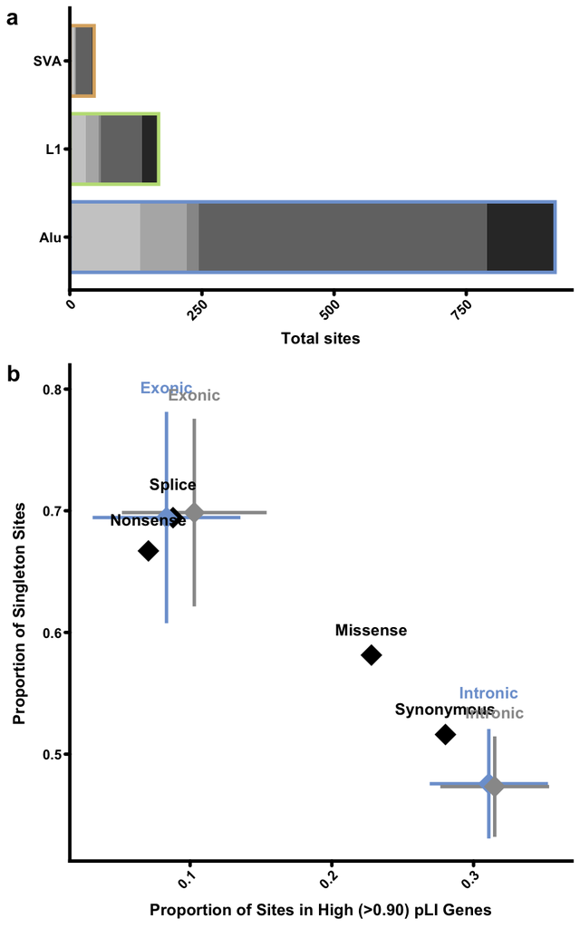

```r
figure2 <- plot_grid(plot.compartment,plot.constraint,ncol=1,nrow=2,align = 'vh', rel_heights = c(2.5,4), labels = c("a","b"))
figure2
```